# GAMM on alpha diversity

Chih-Lin Wei

2026-01-07

```r
## import packages
library(ggrepel)
library(plyr)
library(tidyverse)
library(patchwork)
library(doBy)
library(reshape2)
library(mgcv)
library(knitr)
library(kableExtra)
library(MuMIn)
library(caret)
```

# 1 ggplot theme setting

```r
# plot setting
large <- theme(legend.title = element_text(size=15),
        legend.text = element_text(size=15),
        axis.title = element_text(size=15),
        axis.text = element_text(size=15),
        strip.text = element_text(size=15))
vert_x <- theme(axis.text.x.bottom = element_text(angle = 45, hjust = 1, face="italic"))
no_strip.x <- theme(strip.background.x = element_blank(),
                  strip.text.x = element_blank())
no_strip.y <- theme(strip.background.y = element_blank(),
                  strip.text.y = element_blank())
no_legend <- theme(legend.position = "none")

# Standard error function
se <- function(x, ...)sd(x, ...)/sqrt(length(x))

load(file="../Rdata/mis.rda") # Marine Isotope Stage
load(file="../Rdata/spp.rda") # Raw species count
load(file="../Rdata/sam.rda") # Sample information
load(file="../Rdata/div.rda") # Diversity
zero <- rowSums(spp)==0 # The sample with zero count
```

# 2 Standardized Hill numbers at 90% sample coverage

The standardized Hill numbers were computed in the RMarkdown file **“Okhotsk_Diatom_Alpha_Diversity.Rmd.”** In this section, we will load the saved data directly to analyze the diversity indices. The calculation includes species richness (0D), Shannon diversity (1D), and Simpson diversity (2D), all of which were standardized at a sample coverage of 90%. Additionally, we will assess species evenness by computing the normalized slope of the Hill number profile, which corresponds to the values for evenness (1E and 2E).

# 3 Generalized Additive Mixed-effect Model (GAMM) on species diversity

```r
dat <- melt(div, id.vars = c("Age_ka", "Period", "Period2", "SST", "TOC", "TN", "TP", "TIC", "Dino"), measure.vars = c("DAR", "d0", "d1", "d2", "e1","e2")) %>% group_split(variable)
names(dat) <- c("DAR", "d0", "d1", "d2", "e1","e2")
dat[2:6] <- lapply(dat[2:6], FUN=function(x)x[!zero,])

# GAM Formula
gam_form <- formula(value ~ Period + Period2 + s(SST, bs = "cr", k=7) + s(TOC, bs = "cr", k=7) + s(TOC, bs = "cr", k=7) + s(TN, bs = "cr", k=7) + s(TP, bs = "cr", k=7) + s(TIC, bs = "cr", k=7) + s(Dino, bs = "cr", k=7) + s(Age_ka, bs = "re", k=7))

gam_l <- lapply(dat, FUN=function(x){
  gam(formula = gam_form, family = gaussian(link = "log"), data=x, method="REML", na.action = "na.fail")
})
```

# 4 Global model

The results of the Generalized Additive Models (GAM) are summarized in three tables. The first table presents the parametric coefficients. The second table displays the approximate significance of the smooth terms in the GAMM. The third table shows the adjusted R-squared values, scale estimates of the GAMM, and sample size (n).

```r
# Parametric coefficients
lapply(gam_l, FUN = function(x) {
  out <- summary(x)$p.table %>% as.data.frame
  cbind(Term=row.names(out), out)
  }) %>% ldply(.id = "Order.q") %>% kable(caption="Parametric coefficients") %>% kable_classic
```

Parametric coefficients

| Order.q | Term | Estimate | Std. Error | t value | Pr(>&#124;t&#124;) |
| --- | --- | --- | --- | --- | --- |
| DAR | (Intercept) | 15.7424869 | 0.6545853 | 24.0495588 | 0.0000000 |
| DAR | PeriodGlacial | 0.1362951 | 0.1642956 | 0.8295722 | 0.4071460 |
| DAR | Period2MPT | -3.1936470 | 0.3612948 | -8.8394481 | 0.0000000 |
| DAR | Period2Post | -8.2740126 | 0.6099276 | -13.5655655 | 0.0000000 |
| d0 | (Intercept) | 2.2670241 | 0.0745301 | 30.4175521 | 0.0000000 |
| d0 | PeriodGlacial | -0.0112747 | 0.0294306 | -0.3830945 | 0.7018409 |
| d0 | Period2MPT | 0.0496410 | 0.0681984 | 0.7278911 | 0.4670804 |
| d0 | Period2Post | 0.4078244 | 0.0606217 | 6.7273621 | 0.0000000 |
| d1 | (Intercept) | 1.7358354 | 0.0807757 | 21.4895859 | 0.0000000 |
| d1 | PeriodGlacial | -0.0058101 | 0.0293105 | -0.1982249 | 0.8429650 |
| d1 | Period2MPT | -0.0530994 | 0.0724866 | -0.7325412 | 0.4642468 |
| d1 | Period2Post | 0.4744801 | 0.0646640 | 7.3376284 | 0.0000000 |
| d2 | (Intercept) | 1.3763295 | 0.0847332 | 16.2430956 | 0.0000000 |
| d2 | PeriodGlacial | 0.0135753 | 0.0304418 | 0.4459426 | 0.6558678 |
| d2 | Period2MPT | -0.1315412 | 0.0782341 | -1.6813784 | 0.0934306 |
| d2 | Period2Post | 0.4809893 | 0.0671926 | 7.1583667 | 0.0000000 |
| e1 | (Intercept) | -0.6125746 | 0.0436777 | -14.0248849 | 0.0000000 |
| e1 | PeriodGlacial | 0.0197983 | 0.0149200 | 1.3269685 | 0.1852246 |
| e1 | Period2MPT | -0.1497853 | 0.0334806 | -4.4737925 | 0.0000099 |
| e1 | Period2Post | 0.1044650 | 0.0343921 | 3.0374743 | 0.0025312 |
| e2 | (Intercept) | -1.0782645 | 0.0733937 | -14.6915217 | 0.0000000 |
| e2 | PeriodGlacial | 0.0442262 | 0.0251724 | 1.7569314 | 0.0796426 |
| e2 | Period2MPT | -0.2543533 | 0.0601895 | -4.2258768 | 0.0000291 |
| e2 | Period2Post | 0.1685874 | 0.0573212 | 2.9411019 | 0.0034474 |

```r
# Significance of smooth terms
lapply(gam_l, FUN = function(x) {
  out <- summary(x)$s.table %>% as.data.frame
  cbind(Term=row.names(out), out)
  }) %>% ldply(.id = "Order.q") %>% kable(caption="Significance of smooth terms") %>% kable_classic
```

Significance of smooth terms

| Order.q | Term | edf | Ref.df | F | p-value |
| --- | --- | --- | --- | --- | --- |
| DAR | s(SST) | 5.1411959 | 5.669077 | 14.7773389 | 0.0000000 |
| DAR | s(TOC) | 2.8518169 | 3.202279 | 19.1723588 | 0.0000000 |
| DAR | s(TN) | 5.8042185 | 5.973578 | 16.2942427 | 0.0000000 |
| DAR | s(TP) | 5.9336008 | 5.996145 | 57.3558154 | 0.0000000 |
| DAR | s(TIC) | 1.9719257 | 2.010870 | 13.9374754 | 0.0000017 |
| DAR | s(Dino) | 3.5168866 | 3.940907 | 47.2042661 | 0.0000000 |
| DAR | s(Age_ka) | 0.9950994 | 1.000000 | 190.0186267 | 0.0000000 |
| d0 | s(SST) | 4.1113030 | 4.889949 | 4.1230080 | 0.0028958 |
| d0 | s(TOC) | 1.0009382 | 1.001861 | 0.6060713 | 0.4373480 |
| d0 | s(TN) | 1.0017418 | 1.003456 | 0.8029947 | 0.3716867 |
| d0 | s(TP) | 3.3767846 | 3.914288 | 3.6972798 | 0.0048120 |
| d0 | s(TIC) | 1.0001874 | 1.000371 | 4.3947746 | 0.0366123 |
| d0 | s(Dino) | 1.0002071 | 1.000410 | 4.5456228 | 0.0335504 |
| d0 | s(Age_ka) | 0.7505974 | 1.000000 | 3.0651926 | 0.0429075 |
| d1 | s(SST) | 4.4277160 | 5.175152 | 4.3827057 | 0.0006655 |
| d1 | s(TOC) | 1.0001555 | 1.000306 | 2.1643835 | 0.1419986 |
| d1 | s(TN) | 4.8483037 | 5.392560 | 2.3963624 | 0.0309781 |
| d1 | s(TP) | 2.8826221 | 3.372832 | 3.9418271 | 0.0052247 |
| d1 | s(TIC) | 2.7697013 | 3.081506 | 2.1917718 | 0.0809075 |
| d1 | s(Dino) | 1.0012152 | 1.002412 | 6.6470134 | 0.0102202 |
| d1 | s(Age_ka) | 0.9320860 | 1.000000 | 13.8781635 | 0.0001222 |
| d2 | s(SST) | 4.3936708 | 5.139902 | 4.1751456 | 0.0009421 |
| d2 | s(TOC) | 1.0001106 | 1.000219 | 3.3684181 | 0.0671603 |
| d2 | s(TN) | 5.0206321 | 5.539253 | 2.9241206 | 0.0097956 |
| d2 | s(TP) | 1.3480438 | 1.588956 | 6.7200058 | 0.0061959 |
| d2 | s(TIC) | 3.0239351 | 3.347392 | 3.7830502 | 0.0121024 |
| d2 | s(Dino) | 1.0009235 | 1.001836 | 4.5835243 | 0.0327787 |
| d2 | s(Age_ka) | 0.9588749 | 1.000000 | 23.5613851 | 0.0000011 |
| e1 | s(SST) | 1.0002645 | 1.000528 | 1.4884219 | 0.2231142 |
| e1 | s(TOC) | 1.0000283 | 1.000056 | 2.4985699 | 0.1146851 |
| e1 | s(TN) | 1.0000658 | 1.000131 | 0.3712305 | 0.5426558 |
| e1 | s(TP) | 1.0000582 | 1.000116 | 3.8610949 | 0.0500564 |
| e1 | s(TIC) | 2.8539811 | 3.171647 | 1.9270080 | 0.1045444 |
| e1 | s(Dino) | 1.0001688 | 1.000337 | 0.3484915 | 0.5553457 |
| e1 | s(Age_ka) | 0.9469873 | 1.000000 | 17.9377176 | 0.0000171 |
| e2 | s(SST) | 1.0002298 | 1.000459 | 3.5577435 | 0.0599229 |
| e2 | s(TOC) | 1.0000788 | 1.000157 | 2.4579499 | 0.1176635 |
| e2 | s(TN) | 1.0000549 | 1.000110 | 0.4529436 | 0.5013005 |
| e2 | s(TP) | 1.0000342 | 1.000068 | 4.1412574 | 0.0424620 |
| e2 | s(TIC) | 2.8778365 | 3.196439 | 2.1283346 | 0.0809274 |
| e2 | s(Dino) | 1.0001936 | 1.000387 | 0.0252624 | 0.8742801 |
| e2 | s(Age_ka) | 0.9559889 | 1.000000 | 21.8527952 | 0.0000027 |

```r
# Adjust R squares
out <- lapply(gam_l, FUN=function(x)cbind(summary(x)$r.sq, summary(x)$scale, summary(x)$n)) %>% ldply(.id="Order.q")
names(out)[2:4] <- c("R-sq.(adj)", "Scale est.", "n")
kable(out, caption="Adjusted r-squared for the model") %>% kable_classic
```

Adjusted r-squared for the model

| Order.q | R-sq.(adj) | Scale est. | n |
| --- | --- | --- | --- |
| DAR | 0.9427051 | 1.873048e+06 | 572 |
| d0 | 0.2885759 | 1.003851e+01 | 442 |
| d1 | 0.3579005 | 4.191378e+00 | 442 |
| d2 | 0.3480272 | 2.560151e+00 | 442 |
| e1 | 0.1747788 | 6.235400e-03 | 442 |
| e2 | 0.1782622 | 8.996400e-03 | 442 |

```r
# 10-fold Cross validation
# The 9/10 of the data are used to re-fit the model and 1/10 of data to evaluate model performance (R2).
# Repeat for 5 times
perf_l <- lapply(dat, FUN=function(x){
  cvs <- list()
  for(i in 1:5){
    repeat{
      fold <- createFolds(1:dim(x)[1], k=10)
      cv <- NULL
      for(k in 1:10){
        training_set <- x[-fold[[k]],]
        validation_set <- x[fold[[k]],]
        try(f <- gam(formula = gam_form, family = gaussian(link = "log"), data=training_set, method="REML", na.action = "na.fail"))
        pred <- predict(f, newdata=validation_set, type="response")
        cv <- rbind(cv, cbind(pred, obs = validation_set$value) %>% as.data.frame)
        }
      if(!is(f, "try-error"))
        break
      }
    cvs[[i]] <- defaultSummary(cv)
    }
  m <- ldply(cvs) %>% colMeans
  s <- apply(ldply(cvs), 2, FUN=sd)
  names(s) <- paste(names(s), "SD", sep="")
  c(m, s)
  })

save(perf_l, file="../Rdata/cross_v_r2_all.rda")
```

```r
load("../Rdata/cross_v_r2_all.rda")
kable(perf_l %>% ldply(.id = "Order.q"), caption="Accuracy and performance of the model by 10-fold cross validation, repeated 5 times") %>% kable_classic
```

Accuracy and performance of the model by 10-fold cross validation, repeated 5 times

| Order.q | RMSE | Rsquared | MAE | RMSESD | RsquaredSD | MAESD |
| --- | --- | --- | --- | --- | --- | --- |
| DAR | 5366.8329404 | 0.4875343 | 1338.3447663 | 2051.4158349 | 0.1769658 | 135.6344944 |
| d0 | 3.2371120 | 0.2580510 | 2.5102002 | 0.0134353 | 0.0055524 | 0.0145598 |
| d1 | 2.1475333 | 0.2953698 | 1.6645779 | 0.0093185 | 0.0053857 | 0.0117498 |
| d2 | 1.6742714 | 0.2870516 | 1.2887468 | 0.0075684 | 0.0056039 | 0.0056676 |
| e1 | 0.0813478 | 0.1284092 | 0.0608073 | 0.0003839 | 0.0071295 | 0.0003419 |
| e2 | 0.0974733 | 0.1357325 | 0.0737768 | 0.0007285 | 0.0104977 | 0.0006226 |

## 4.1 Model validation for normality and homogeneity

The model assumptions of GAMM were validated by visual inspection of residual, observation, and prediction distributions. We used the normal Q-Q Plot to compare the quantiles of the residuals against the quantiles of a standard normal distribution. A straight line indicates that the residuals are approximately normally distributed. The residual histogram provides a visual representation of the distribution of the residuals, illustrating the frequency of residual values. Any skewness or kurtosis would indicate deviations of residuals from normality. We also examine the assumption of homogeneity by checking whether the residuals are spread evenly around zero across all levels of the predictor variables and whether their variance remains consistent across different groups or transects. A random scatter of points around zero suggests homogeneity, while any discernible pattern may indicate a problem with the model, such as non-constant variance (heteroscedasticity).

- **Model Assumption on Normal Distribution**: These analyses evaluate whether the residuals (the differences between the observed and predicted values) of the model are normally distributed.
  - **Normal Q-Q Plot** compares the quantiles of the residuals with the quantiles of a standard normal distribution. A straight line in this plot indicates that the residuals are approximately normally distributed.
  - **Histogram of Residuals** provides a visual representation of the distribution of the residuals. It helps illustrate the frequency of residual values, suggesting any skewness or kurtosis that may indicate deviations from normality.
- **Model Assumption on Homogeneity**: These analyses check whether the residuals are spread evenly around zero across all levels of the predictor variables and whether their variance remains consistent across different groups or transects.
  - **Residuals vs. Fitted Values Plot** illustrates the relationship between the predicted values (fitted values) from the model and the residuals. A random scatter of points around zero suggests homogeneity, while any discernible pattern may indicate a problem with the model, such as non-constant variance (heteroscedasticity).
- **Model Fit**: These analyses assess the overall performance and accuracy of the model in predicting the response variable.
  - **Response vs. Fitted Values Plot** compares the actual observed values of the response variable against the values predicted by the model. A tighter cluster of points along a 45-degree line indicates a better fit, reflecting high predictive accuracy and minimal error.

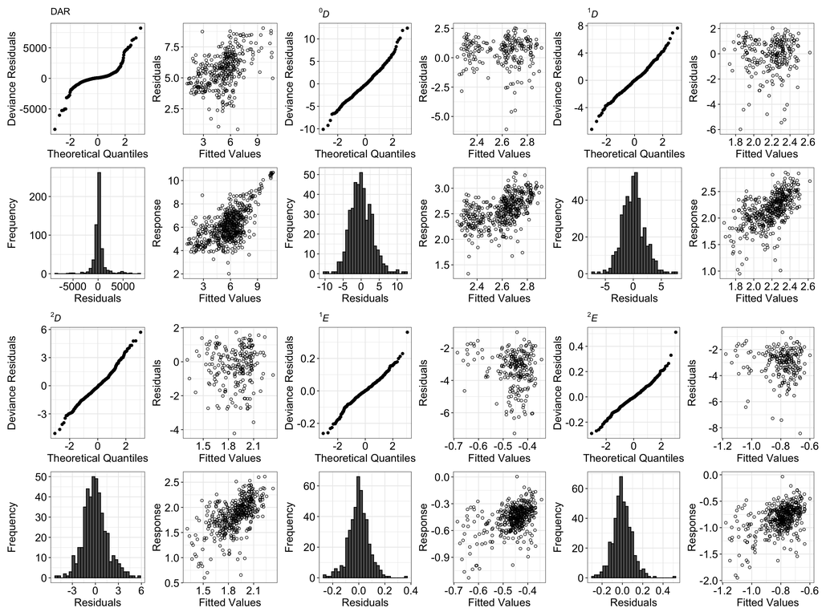

```r
gam_l$DAR$title <- "DAR"
gam_l$d0$title <- expression(""^0*italic(D))
gam_l$d1$title <- expression(""^1*italic(D))
gam_l$d2$title <- expression(""^2*italic(D))
gam_l$e1$title <- expression(""^1*italic(E))
gam_l$e2$title <- expression(""^2*italic(E))

lapply(gam_l, FUN=function(x){
  p1<- ggplot() +
    stat_qq(aes(sample = residuals(x))) +
    labs(x = "Theoretical Quantiles", y = "Deviance Residuals", title = parse(text=x$title))+
    theme_bw() %+replace% large
  p2 <- ggplot(data=cbind(p=predict(x), r=residuals(x))) +
    geom_point(aes(x=p, y=log(r)), shape = 1) +
    labs(x = "Fitted Values", y = "Residuals")+
    theme_bw() %+replace% large
  p3 <- ggplot() +
    geom_histogram(aes(residuals(x)), colour="black") +
    labs(x = "Residuals", y = "Frequency")+
    theme_bw() %+replace% large
  p4 <- ggplot() +
    geom_point(aes(x= predict(x), y = log(x$y)), shape = 1) +
    labs(x = "Fitted Values", y = "Response")+
    theme_bw() %+replace% large
  p1+p2+p3+p4
}) %>% wrap_plots
```

## 4.2 Soomth compnents of the fitted GAM

```r
gam_pred <- lapply(gam_l, FUN=function(x){
  out <- plot(x, residuals = TRUE, page=1)
  names(out) <- names(x$model)[names(x$model) %in% c("Age_ka", "SST", "TOC", "TN", "TP", "TIC", "Dino")]
  lapply(out[!names(out)=="Age_ka"], FUN = function(x){
    out <- cbind(x$x, x$fit, x$se, x$raw, x$p.resid) %>% as.data.frame
    names(out) <- c("x", "fit", "se", "rug", "p.resid")
    return(out)
  }) %>% ldply(.id = "env")
}) %>% ldply(.id = "var")

gam_pred$label <- factor(gam_pred$var,
                             labels = c("DAR", expression(""^0*italic(D)), expression(""^1*italic(D)),
                                        expression(""^2*italic(D)), expression(""^1*italic(E)),
                                        expression(""^2*italic(E))
                                        ))
```

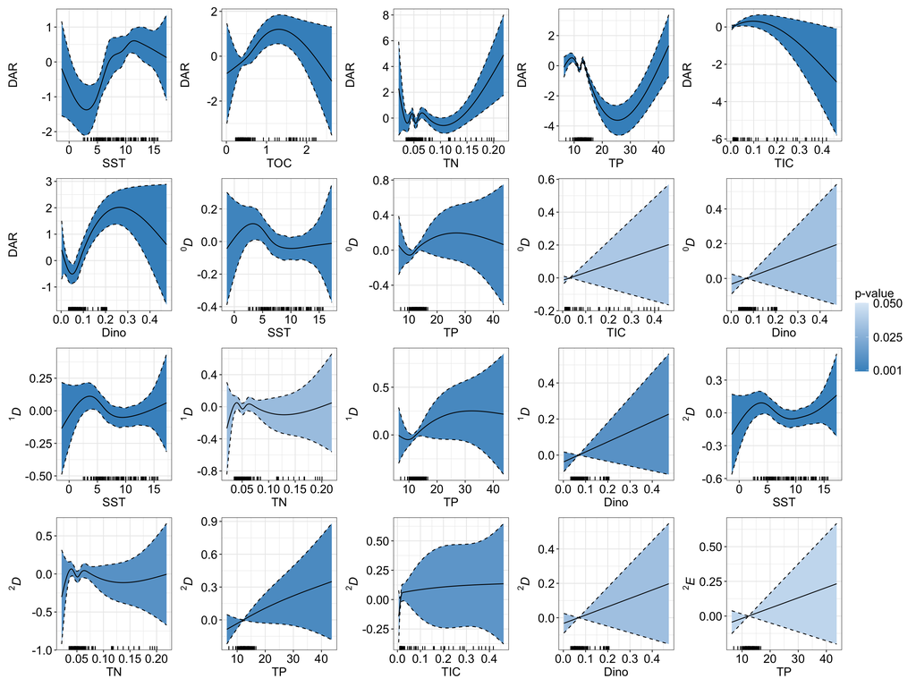

```r
library(stringr)

pv <- lapply(gam_l, FUN = function(x) {
  out <- summary(x)$s.table %>% as.data.frame
  cbind(Term=row.names(out), out)
  }) %>% ldply(.id = "var")

pv$env <- gsub(".*\\((.*)\\).*", "\\1", pv$Term)

keep <- match(with(gam_pred, paste(var, env)), with(pv, paste(var, env)))
gam_pred$pvalue <- pv$`p-value`[keep]

lapply(subset(gam_pred, pvalue<0.05) %>% group_split(var, env), FUN=function(x){
  ggplot(data=x)+
    geom_ribbon(aes(x=x, ymin=fit-se*1.9, ymax=fit+se*1.9, fill=pvalue))+
    #geom_point(aes(x=x, y=fit+p.resid), colour = "gray60")+
    geom_line(aes(x=x, y=fit))+
    geom_line(aes(x=x, y=fit-se*1.9), linetype=2)+
    geom_line(aes(x=x, y=fit+se*1.9), linetype=2)+
    geom_rug(aes(x=rug), sides="b")+
    scale_fill_gradient(low = "#4292c6", high = "#deebf7", breaks = c(0.001, 0.025, 0.05), limits = c(0, 0.05), na.value = "white")+
    labs(x=x$env[1], y = parse(text=as.character(x$label[1])), fill = "p-value")+
    theme_bw() %+replace% large
}) %>% wrap_plots() +
  plot_layout(guides = "collect") & theme(legend.position = "right")
```

# 5 Model selction

Model selection was developed by repeatedly evaluating a subset of candidate models from a global model, including all potential predictor variables. The comparison and ranking of these models are based on AICc, which is an adjustment of the standard Akaike Information Criterion (AIC) that incorporates a correction for small sample sizes relative to the number of model parameters. Models with lower AICc values are considered to provide a better fit to the data for a given number of parameters, indicating a better balance between model complexity and goodness of fit [(Anderson and Burnham, 2002)](https://doi.org/10.2307/3803155). The model with the lowest AICc is considered the “best” model in the candidate set. We used delta AICc (ΔAICc) to examine the difference between the AICc of each model and the AICc of the best-ranked model. Then, the Akaike Weights (weight) are derived from the ΔAICc values to measure the relative likelihood of each model being the best model. Akaike weights sum to one across all considered models. A model with a higher weight is more likely to be the best approximating model.

## 5.1 Model comparisons based on AICc

```r
f1 <- gam(formula = value ~ Period + Period2 + s(SST, bs = "cr", k=7) + s(TOC, bs = "cr", k=7) + s(TN, bs = "cr", k=7) + s(TP, bs = "cr", k=7) + s(TIC, bs = "cr", k=7) + s(Dino, bs = "cr", k=7) + s(Age_ka, bs = "re", k=7), family = gaussian(link = "log"), data=dat$DAR, method="REML", na.action = "na.fail")

f2 <- gam(formula = value ~ Period + Period2 + s(SST, bs = "cr", k=7) + s(TOC, bs = "cr", k=7) + s(TN, bs = "cr", k=7) + s(TP, bs = "cr", k=7) + s(TIC, bs = "cr", k=7) + s(Dino, bs = "cr", k=7) + s(Age_ka, bs = "re", k=7), family = gaussian(link = "log"), data=dat$d0, method="REML", na.action = "na.fail")

f3 <- gam(formula = value ~ Period + Period2 + s(SST, bs = "cr", k=7) + s(TOC, bs = "cr", k=7) + s(TN, bs = "cr", k=7) + s(TP, bs = "cr", k=7) + s(TIC, bs = "cr", k=7) + s(Dino, bs = "cr", k=7) + s(Age_ka, bs = "re", k=7), family = gaussian(link = "log"), data=dat$d1, method="REML", na.action = "na.fail")

f4 <- gam(formula = value ~ Period + Period2 + s(SST, bs = "cr", k=7) + s(TOC, bs = "cr", k=7) + s(TN, bs = "cr", k=7) + s(TP, bs = "cr", k=7) + s(TIC, bs = "cr", k=7) + s(Dino, bs = "cr", k=7) + s(Age_ka, bs = "re", k=7), family = gaussian(link = "log"), data=dat$d2, method="REML", na.action = "na.fail")

f5 <- gam(formula = value ~ Period + Period2 + s(SST, bs = "cr", k=7) + s(TOC, bs = "cr", k=7) + s(TN, bs = "cr", k=7) + s(TP, bs = "cr", k=7) + s(TIC, bs = "cr", k=7) + s(Dino, bs = "cr", k=7) + s(Age_ka, bs = "re", k=7), family = gaussian(link = "log"), data=dat$e1, method="REML", na.action = "na.fail")

f6 <- gam(formula = value ~ Period + Period2 + s(SST, bs = "cr", k=7) + s(TOC, bs = "cr", k=7) + s(TN, bs = "cr", k=7) + s(TP, bs = "cr", k=7) + s(TIC, bs = "cr", k=7) + s(Dino, bs = "cr", k=7), family = gaussian(link = "log"), data=dat$e2, method="REML", na.action = "na.fail")

f <- list(f1, f2, f3, f4, f5, f6)
names(f) <- c("DAR", "d0", "d1", "d2", "e1","e2")

ms1 <- dredge(f1, extra = c("R^2", "adjR^2"))
ms2 <- dredge(f2, extra = c("R^2", "adjR^2"))
ms3 <- dredge(f3, extra = c("R^2", "adjR^2"))
ms4 <- dredge(f4, extra = c("R^2", "adjR^2"))
ms5 <- dredge(f5, extra = c("R^2", "adjR^2"))
ms6 <- dredge(f6, extra = c("R^2", "adjR^2"))
ms <- list(ms1, ms2, ms3, ms4, ms5, ms6)
names(ms) <- c("DAR", "d0", "d1", "d2", "e1","e2")

save(ms, file="../Rdata/ms_concentration.rda")
```

```r
load("../Rdata/ms_concentration.rda")
lapply(ms, FUN=function(x)(x[1:10,])) %>% ldply(.id="Order.q") %>% kable(caption = "Model coefficients and ranking statistics. Each row represents one model.") %>% kable_classic
```

Model coefficients and ranking statistics. Each row represents one model.

Order.q

(Intercept)

Period

Period2

s(Age_ka, bs = “re”, k = 7)

s(Dino, bs = “cr”, k = 7)

s(SST, bs = “cr”, k = 7)

s(TIC, bs = “cr”, k = 7)

s(TN, bs = “cr”, k = 7)

s(TOC, bs = “cr”, k = 7)

s(TP, bs = “cr”, k = 7)

R^2

adjR^2

df

logLik

AICc

delta

weight

DAR

15.6560621

NA

0.9448653

0.9448653

31

-4926.9823

9921.3957

0.0000000

7.282891e-01

DAR

15.7424869

0.9448943

0.9448943

32

-4926.8321

9923.3676

1.9719211

2.717106e-01

DAR

16.3090710

NA

0.9414977

0.9414977

30

-4943.9386

9951.8649

30.4692530

1.761934e-07

DAR

16.2411388

NA

NA

0.9410267

0.9410267

29

-4946.2320

9953.7862

32.3905680

6.741885e-08

DAR

17.3478554

NA

0.9407176

0.9407176

28

-4947.7270

9956.4933

35.0976039

1.741630e-08

DAR

18.7561404

NA

NA

0.9395113

0.9395113

28

-4953.4879

9968.0264

46.6307116

5.452221e-11

DAR

16.2058414

NA

NA

0.9383617

0.9383617

28

-4958.8725

9978.0211

56.6254656

3.683326e-13

DAR

16.1565942

NA

0.9383883

0.9383884

29

-4958.7489

9979.8076

58.4119868

1.507655e-13

DAR

14.2870739

NA

NA

0.9356765

0.9356765

25

-4971.0683

9994.8517

73.4560677

8.156830e-17

DAR

14.2802577

NA

0.9357214

0.9357214

26

-4970.8684

9996.6725

75.2768208

3.282085e-17

d0

2.2564099

NA

NA

0.3122744

0.3135786

16

-1128.9035

2292.8572

0.0000000

1.751388e-01

d0

2.2417211

NA

NA

NA

0.3078212

0.3091067

15

-1130.3299

2293.0620

0.2048089

1.580915e-01

d0

2.2661992

NA

NA

NA

NA

0.3050281

0.3063020

14

-1131.2199

2293.1357

0.2785114

1.523717e-01

d0

2.2567218

NA

NA

0.3103125

0.3116084

16

-1129.5330

2293.8938

1.0365872

1.043014e-01

d0

2.2728964

NA

NA

NA

0.3107350

0.3120326

16

-1129.3976

2294.1102

1.2529939

9.360479e-02

d0

2.2603625

NA

0.3129445

0.3142514

17

-1128.6880

2294.7164

1.8591540

6.913088e-02

d0

2.2613077

NA

0.3121293

0.3134328

17

-1128.9501

2294.7647

1.9075285

6.747885e-02

d0

2.3029345

NA

NA

NA

NA

0.3013055

0.3025639

14

-1132.4005

2294.8463

1.9890804

6.478268e-02

d0

2.3789907

NA

NA

NA

0.3056782

0.3069548

15

-1131.0131

2295.0455

2.1882761

5.864137e-02

d0

2.2675452

NA

NA

NA

0.3053651

0.3066404

15

-1131.1127

2295.1214

2.2641607

5.645807e-02

d1

1.7358354

0.3882653

0.3917875

25

-932.6599

1918.4886

0.0000000

4.578153e-01

d1

1.7324322

NA

0.3779990

0.3814280

22

-936.3380

1919.7441

1.2554350

2.443858e-01

d1

1.7291012

NA

NA

0.3590632

0.3623205

17

-942.9656

1922.3332

3.8445599

6.696605e-02

d1

1.7393031

NA

NA

NA

0.3547931

0.3580116

16

-944.4331

1922.8134

4.3247741

5.267172e-02

d1

1.7360753

NA

NA

NA

0.3546276

0.3578447

16

-944.4897

1923.1778

4.6891183

4.389966e-02

d1

1.7694144

NA

NA

0.3691420

0.3724907

21

-939.4627

1923.6460

5.1573335

3.473678e-02

d1

1.7143361

NA

NA

NA

NA

0.3498775

0.3530514

15

-946.1104

1923.7569

5.2682484

3.286281e-02

d1

1.7306938

NA

NA

0.3536261

0.3568340

16

-944.8324

1924.3277

5.8390082

2.470391e-02

d1

1.7240188

NA

0.3585528

0.3618055

18

-943.1415

1924.6353

6.1466260

2.118202e-02

d1

1.7414341

NA

NA

0.3556447

0.3588709

17

-944.1412

1924.6740

6.1853418

2.077593e-02

d2

1.3820936

NA

0.3775861

0.3833145

22

-824.1661

1696.4948

0.0000000

4.942589e-01

d2

1.3763295

0.3772060

0.3829287

23

-824.3010

1698.6189

2.1240960

1.708885e-01

d2

1.4374922

NA

NA

0.3712979

0.3769309

21

-826.3877

1698.7882

2.2933773

1.570196e-01

d2

1.4329488

NA

0.3709342

0.3765618

22

-826.5155

1700.9508

4.4560205

5.325274e-02

d2

1.4294466

NA

NA

NA

0.3650154

0.3705531

20

-828.5851

1701.3340

4.8392202

4.396744e-02

d2

1.3960526

NA

NA

0.3667882

0.3723528

22

-827.9672

1702.4224

5.9276076

2.551472e-02

d2

1.4415422

NA

NA

NA

0.3606294

0.3661006

20

-830.1064

1702.8925

6.3976744

2.017052e-02

d2

1.4220955

NA

NA

0.3647854

0.3703197

21

-828.6651

1703.3909

6.8961026

1.572117e-02

d2

1.3843352

NA

0.3658565

0.3714070

22

-828.2922

1704.2029

7.7080630

1.047538e-02

d2

1.3882963

NA

NA

NA

0.3573586

0.3627802

20

-831.2341

1704.5672

8.0723594

8.730998e-03

e1

-0.6150353

NA

NA

NA

NA

0.1918162

-0.0283487

10

500.0701

-979.0982

0.0000000

2.456464e-01

e1

-0.6027201

NA

NA

NA

0.1937357

-0.0286324

11

500.5956

-977.9629

1.1353029

1.392460e-01

e1

-0.6213191

NA

NA

NA

0.1925842

-0.0284622

11

500.2802

-977.4188

1.6794609

1.060767e-01

e1

-0.6097335

NA

NA

0.1958061

-0.0289384

12

501.1639

-977.2130

1.8852781

9.570344e-02

e1

-0.6126918

NA

NA

NA

0.1920862

-0.0283886

11

500.1440

-977.1630

1.9352741

9.334070e-02

e1

-0.6115950

NA

NA

NA

NA

NA

0.1843615

-0.0272470

9

498.0410

-977.0382

2.0600333

8.769603e-02

e1

-0.6491189

NA

NA

NA

0.1910568

-0.0282365

11

499.8626

-976.5058

2.5924363

6.720013e-02

e1

-0.6088567

NA

NA

0.1943069

-0.0287168

12

500.7523

-976.1737

2.9245644

5.691797e-02

e1

-0.5991051

NA

NA

0.1941924

-0.0286999

12

500.7208

-976.1198

2.9784826

5.540401e-02

e1

-0.6215258

NA

NA

NA

NA

0.1774526

-0.0262259

7

496.1769

-976.0223

3.0759550

5.276857e-02

e2

-0.7771372

NA

NA

NA

NA

0.1405958

-0.0322456

8

404.5423

-792.7490

0.0000000

1.517969e-01

e2

-0.7645887

NA

NA

NA

0.1517032

-0.0347931

10

407.4173

-792.3110

0.4379920

1.219422e-01

e2

-0.7848781

NA

NA

NA

NA

NA

0.1354502

-0.0310655

7

403.2230

-792.1863

0.5627183

1.145698e-01

e2

-0.7746802

NA

NA

NA

0.1434321

-0.0328961

9

405.2729

-792.1270

0.6220001

1.112237e-01

e2

-0.7630288

NA

NA

0.1550478

-0.0355602

11

408.2903

-791.9237

0.8252728

1.004748e-01

e2

-0.7437329

NA

NA

NA

NA

0.1477228

-0.0338802

10

406.3827

-791.8802

0.8688146

9.831100e-02

e2

-0.7822790

NA

NA

NA

NA

0.1383996

-0.0317419

8

403.9783

-791.6149

1.1340956

8.609880e-02

e2

-0.7737821

NA

NA

NA

NA

0.1456873

-0.0334133

9

405.8555

-791.3874

1.3616233

7.684048e-02

e2

-0.7728070

NA

NA

NA

0.1416631

-0.0324904

9

404.8169

-791.2107

1.5382885

7.034410e-02

e2

-0.7436526

NA

NA

NA

0.1527839

-0.0350410

11

407.6990

-791.1546

1.5943907

6.839830e-02

## 5.2 Model averaging and variable importance

We averaged the parameter estimates across all candidate models, with each estimate weighted by its Akaike weight. These weights indicate the relative support for each candidate model [(Anderson et al., 2000)](https://doi.org/10.2307/3803199). The model averaging accounted for uncertainty in model selection and provided appropriate confidence intervals. The relative importance of a predictor variable is then determined by summing the Akaike weights of all the models in the candidate set that include that specific predictor variable [(Burnham and Anderson, 2002)](https://doi.org/10.2307/3803155). For instance, if a predictor variable appears in many of the “good” models (i.e., models with high Akaike weights), its relative importance will be high, suggesting that the variable is a strong predictor of the response variable, as it consistently contributes to well-fitting models. Conversely, if a predictor variable only appears in models with low Akaike weights, its relative importance will be low, indicating that it is less important for explaining the variation in the response.

```r
ma <- lapply(ms, FUN=function(x) model.avg(x, rank="AICc", fit=TRUE))
save(ma, file="../Rdata/ma_concentration.rda")
```

```r
load("../Rdata/ma_concentration.rda")

#lapply(ma, FUN=function(x){
#  d <- summary(x)$msTable %>% as.data.frame
#  cbind(Term.code=row.names(d), d)
#  }) %>% ldply(.id="Order.q") %>%kable(caption = "Log-likelihood, AICc, ΔAICc and ‘Akaike weights’ for the component models") %>%kable_classic

#lapply(ma, FUN=function(x){
#  d <- summary(x)$coefmat.full %>% as.data.frame
#  cbind(Term=row.names(d), d)
#  }) %>% ldply(.id="Order.q") %>%kable(caption = "Full model-averaged coefficients. The ‘full’ average assumes that all variable are included in every model, but in some models the corresponding coefficient is set to zero during model selection.") %>%kable_classic


nam <- c("Period", "Period2", "s(SST, bs = \"cr\", k = 7)", "s(TOC, bs = \"cr\", k = 7)", "s(TN, bs = \"cr\", k = 7)", "s(TP, bs = \"cr\", k = 7)", "s(TIC, bs = \"cr\", k = 7)", "s(Dino, bs = \"cr\", k = 7)", "s(Age_ka, bs = \"re\", k = 7)")

imp <- lapply(ma, FUN=function(x)summary(x)$sw[nam])%>%ldply(.id="Variable")
names(imp) <- c("Variable", "Period", "Period2", "SST", "TOC", "TN", "TP", "TIC", "Dino", "Age_ka")
imp %>% kable(caption = "Per-model term sum of model Akaike weights over all of the models")%>%kable_classic
```

Per-model term sum of model Akaike weights over all of the models

| Variable | Period | Period2 | SST | TOC | TN | TP | TIC | Dino | Age_ka |
| --- | --- | --- | --- | --- | --- | --- | --- | --- | --- |
| DAR | 0.2717108 | 1 | 1.0000000 | 1.0000000 | 1.0000000 | 1.0000000 | 0.9999998 | 1.0000000 | 1.0000000 |
| d0 | 0.2888406 | 1 | 0.9876019 | 0.4033075 | 0.3589459 | 0.9844555 | 0.5795728 | 0.6866514 | 0.6980422 |
| d1 | 0.4690290 | 1 | 0.9913709 | 0.8125823 | 0.7948428 | 0.9100607 | 0.7956129 | 0.9124177 | 0.9957748 |
| d2 | 0.2621658 | 1 | 0.9974404 | 0.9152707 | 0.9879701 | 0.9147196 | 0.9853216 | 0.7008653 | 0.9999561 |
| e1 | 0.4589064 | 1 | 0.3802416 | 0.6952547 | 0.4053567 | 0.6818228 | 0.6550892 | 0.3659736 | 0.9998620 |
| e2 | 0.7136739 | 1 | 0.8576708 | 0.8047787 | 0.5123083 | 0.5922682 | 0.5316352 | 0.3068440 | NA |

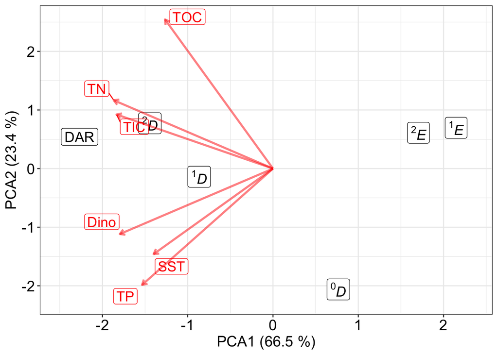

```r
pca <- scale(imp[, c("SST", "TOC", "TN", "TP", "TIC", "Dino")]) %>% prcomp
out <- as.data.frame(pca$x)
out$label <- c("DAR", "\"\"^0 * italic(D)", "\"\"^1 * italic(D)", "\"\"^2 * italic(D)", "\"\"^1 * italic(E)", "\"\"^2 * italic(E)")
lab <- data.frame(pca$rotation*4)
lab$label <- row.names(lab)
# Variance explained by PC axes
a1 <- round(summary(pca)$importance[2,1]*100, 1)
a2 <- round(summary(pca)$importance[2,2]*100, 1)

ggplot()+
    geom_label_repel(data=out, aes(x=PC1, y=PC2, label=label), parse=TRUE, size=5)+
    geom_segment(data=lab, aes(x=0, y=0, xend=PC1, yend=PC2), size=1, arrow = arrow(length = unit(0.2,"cm")), colour=alpha("red", 0.5))+
    geom_label_repel(data=lab, aes(x=PC1, y=PC2, label=label), colour="red", fill="transparent", size=5, label.padding = unit(0.2, "lines"))+
    labs(x=paste("PCA1 (", a1, " %)", sep=""), y=paste("PCA2 (", a2, " %)", sep=""))+
    theme_bw() %+replace% large
```

## 5.3 Summary of the top model

```r
gam_t <- lapply(ms, FUN=function(x)get.models(x, subset=1)[[1]])

# Parametric coefficients
lapply(gam_t, FUN = function(x) {
  out <- summary(x)$p.table %>% as.data.frame
  cbind(Term=row.names(out), out)
  }) %>% ldply(.id = "Order.q") %>% kable(caption="Parametric coefficients") %>% kable_classic
```

Parametric coefficients

| Order.q | Term | Estimate | Std. Error | t value | Pr(>&#124;t&#124;) |
| --- | --- | --- | --- | --- | --- |
| DAR | (Intercept) | 15.6560621 | 0.6472763 | 24.1876038 | 0.0000000 |
| DAR | Period2MPT | -3.0777144 | 0.3389766 | -9.0794312 | 0.0000000 |
| DAR | Period2Post | -8.1005872 | 0.5844413 | -13.8603949 | 0.0000000 |
| d0 | (Intercept) | 2.2564099 | 0.0736120 | 30.6527378 | 0.0000000 |
| d0 | Period2MPT | 0.0451076 | 0.0678012 | 0.6652911 | 0.5062230 |
| d0 | Period2Post | 0.4101593 | 0.0604520 | 6.7848711 | 0.0000000 |
| d1 | (Intercept) | 1.7358354 | 0.0807757 | 21.4895859 | 0.0000000 |
| d1 | PeriodGlacial | -0.0058101 | 0.0293105 | -0.1982249 | 0.8429650 |
| d1 | Period2MPT | -0.0530994 | 0.0724866 | -0.7325412 | 0.4642468 |
| d1 | Period2Post | 0.4744801 | 0.0646640 | 7.3376284 | 0.0000000 |
| d2 | (Intercept) | 1.3820936 | 0.0835190 | 16.5482569 | 0.0000000 |
| d2 | Period2MPT | -0.1281421 | 0.0778503 | -1.6460077 | 0.1005065 |
| d2 | Period2Post | 0.4831689 | 0.0669421 | 7.2177157 | 0.0000000 |
| e1 | (Intercept) | -0.6150353 | 0.0398234 | -15.4440735 | 0.0000000 |
| e1 | Period2MPT | -0.1419480 | 0.0304440 | -4.6625874 | 0.0000042 |
| e1 | Period2Post | 0.1187257 | 0.0299745 | 3.9608963 | 0.0000873 |
| e2 | (Intercept) | -0.7771372 | 0.0239775 | -32.4111350 | 0.0000000 |
| e2 | PeriodGlacial | 0.0568172 | 0.0251125 | 2.2625040 | 0.0241588 |
| e2 | Period2MPT | -0.3392110 | 0.0566412 | -5.9887714 | 0.0000000 |
| e2 | Period2Post | -0.0445786 | 0.0284266 | -1.5682015 | 0.1175612 |

```r
# Significance of smooth terms
lapply(gam_t, FUN = function(x) {
  out <- summary(x)$s.table %>% as.data.frame
  cbind(Term=row.names(out), out)
  }) %>% ldply(.id = "Order.q") %>% kable(caption="Significance of smooth terms") %>% kable_classic
```

Significance of smooth terms

| Order.q | Term | edf | Ref.df | F | p-value |
| --- | --- | --- | --- | --- | --- |
| DAR | s(Age_ka) | 0.9950840 | 1.000000 | 190.788216 | 0.0000000 |
| DAR | s(Dino) | 3.4879962 | 3.901228 | 48.804286 | 0.0000000 |
| DAR | s(SST) | 5.1619452 | 5.682295 | 14.430705 | 0.0000000 |
| DAR | s(TIC) | 1.9780948 | 2.013050 | 17.326691 | 0.0000000 |
| DAR | s(TN) | 5.8189686 | 5.976583 | 18.258315 | 0.0000000 |
| DAR | s(TOC) | 2.8618271 | 3.213969 | 19.384331 | 0.0000000 |
| DAR | s(TP) | 5.9335921 | 5.996179 | 57.908059 | 0.0000000 |
| d0 | s(Age_ka) | 0.7670850 | 1.000000 | 3.367609 | 0.0359407 |
| d0 | s(Dino) | 1.0005283 | 1.001046 | 4.194106 | 0.0411044 |
| d0 | s(SST) | 4.1580926 | 4.926115 | 4.170729 | 0.0021290 |
| d0 | s(TIC) | 1.0003606 | 1.000713 | 4.385576 | 0.0367914 |
| d0 | s(TOC) | 1.0006760 | 1.001335 | 1.798704 | 0.1806694 |
| d0 | s(TP) | 3.4053735 | 3.945198 | 3.955853 | 0.0030776 |
| d1 | s(Age_ka) | 0.9320860 | 1.000000 | 13.878163 | 0.0001222 |
| d1 | s(Dino) | 1.0012152 | 1.002412 | 6.647013 | 0.0102202 |
| d1 | s(SST) | 4.4277160 | 5.175152 | 4.382706 | 0.0006655 |
| d1 | s(TIC) | 2.7697013 | 3.081506 | 2.191772 | 0.0809075 |
| d1 | s(TN) | 4.8483037 | 5.392560 | 2.396362 | 0.0309781 |
| d1 | s(TOC) | 1.0001555 | 1.000306 | 2.164384 | 0.1419986 |
| d1 | s(TP) | 2.8826221 | 3.372832 | 3.941827 | 0.0052247 |
| d2 | s(Age_ka) | 0.9590665 | 1.000000 | 23.661852 | 0.0000011 |
| d2 | s(Dino) | 1.0011228 | 1.002232 | 4.535927 | 0.0336751 |
| d2 | s(SST) | 4.3924925 | 5.138077 | 4.280551 | 0.0007637 |
| d2 | s(TIC) | 3.0544717 | 3.375574 | 3.713177 | 0.0068650 |
| d2 | s(TN) | 5.0319041 | 5.548001 | 3.032154 | 0.0077570 |
| d2 | s(TOC) | 1.0001304 | 1.000258 | 3.780390 | 0.0525189 |
| d2 | s(TP) | 1.4487938 | 1.723153 | 6.825483 | 0.0051856 |
| e1 | s(Age_ka) | 0.9543024 | 1.000000 | 20.938036 | 0.0000042 |
| e1 | s(TIC) | 2.9402775 | 3.254634 | 2.437517 | 0.0474535 |
| e1 | s(TOC) | 1.0002071 | 1.000413 | 8.622239 | 0.0034961 |
| e1 | s(TP) | 1.0001356 | 1.000271 | 4.544389 | 0.0335807 |
| e2 | s(SST) | 1.0006539 | 1.001307 | 6.537859 | 0.0108707 |
| e2 | s(TOC) | 1.0000308 | 1.000062 | 14.026087 | 0.0002046 |
| e2 | s(TP) | 1.0000581 | 1.000116 | 2.947410 | 0.0867158 |

```r
# Adjust R squares
out <- lapply(gam_t, FUN=function(x)cbind(summary(x)$r.sq, summary(x)$scale, summary(x)$n)) %>% ldply(.id="Order.q")
names(out)[2:4] <- c("R-sq.(adj)", "Scale est.", "n")
kable(out, caption="Adjusted r-squared for the model") %>% kable_classic
```

Adjusted r-squared for the model

| Order.q | R-sq.(adj) | Scale est. | n |
| --- | --- | --- | --- |
| DAR | 0.9427352 | 1.870658e+06 | 572 |
| d0 | 0.2908359 | 1.000662e+01 | 442 |
| d1 | 0.3579005 | 4.191378e+00 | 442 |
| d2 | 0.3497508 | 2.553387e+00 | 442 |
| e1 | 0.1770847 | 6.218000e-03 | 442 |
| e2 | 0.1287405 | 9.538500e-03 | 442 |

```r
# 10-fold Cross validation
# The 9/10 of the data are used to re-fit the model and 1/10 of data to evaluate model performance (R2).
# Repeat for 5 times
perf_t <- lapply(dat, FUN=function(x){
  cvs <- list()
  for(i in 1:5){
    repeat{
      fold <- createFolds(1:dim(x)[1], k=10)
      cv <- NULL
      for(k in 1:10){
        training_set <- x[-fold[[k]],]
        validation_set <- x[fold[[k]],]
        try(f <- gam(formula = gam_t[[x$variable[1]]] %>% formula, family = gaussian(link = "log"), data=training_set, method="REML", na.action = "na.fail"))
        pred <- predict(f, newdata=validation_set, type="response")
        cv <- rbind(cv, cbind(pred, obs = validation_set$value) %>% as.data.frame)
        }
      if(!is(f, "try-error"))
        break
      }
    cvs[[i]] <- defaultSummary(cv)
    }
  m <- ldply(cvs) %>% colMeans
  s <- apply(ldply(cvs), 2, FUN=sd)
  names(s) <- paste(names(s), "SD", sep="")
  c(m, s)
  })
save(perf_t, file="../Rdata/cross_v_r2_top.rda")
```

```r
load("../Rdata/cross_v_r2_top.rda")
kable(perf_t %>% ldply(.id = "Order.q"), caption="Accuracy and performance of the model by 10-fold cross validation, repeated 5 times") %>% kable_classic
```

Accuracy and performance of the model by 10-fold cross validation, repeated 5 times

| Order.q | RMSE | Rsquared | MAE | RMSESD | RsquaredSD | MAESD |
| --- | --- | --- | --- | --- | --- | --- |
| DAR | 1.003382e+04 | 0.4147705 | 1477.0283732 | 8595.6567260 | 0.3540001 | 467.1737442 |
| d0 | 3.228882e+00 | 0.2614088 | 2.5003652 | 0.0116762 | 0.0047070 | 0.0112047 |
| d1 | 2.145410e+00 | 0.2968215 | 1.6683020 | 0.0160398 | 0.0094046 | 0.0170951 |
| d2 | 1.670664e+00 | 0.2898998 | 1.2881555 | 0.0067992 | 0.0050430 | 0.0120160 |
| e1 | 8.057120e-02 | 0.1409942 | 0.0605562 | 0.0003588 | 0.0067722 | 0.0003842 |
| e2 | 9.857050e-02 | 0.1126909 | 0.0754655 | 0.0001845 | 0.0031614 | 0.0001641 |

## 5.4 Model validation for normality and homogeneity

- **Model Assumption on Normal Distribution**: These analyses evaluate whether the residuals (the differences between the observed and predicted values) of the model are normally distributed.
  - **Normal Q-Q Plot** compares the quantiles of the residuals with the quantiles of a standard normal distribution. A straight line in this plot indicates that the residuals are approximately normally distributed.
  - **Histogram of Residuals** provides a visual representation of the distribution of the residuals. It helps illustrate the frequency of residual values, suggesting any skewness or kurtosis that may indicate deviations from normality.
- **Model Assumption on Homogeneity**: These analyses check whether the residuals are spread evenly around zero across all levels of the predictor variables and whether their variance remains consistent across different groups or transects.
  - **Residuals vs. Fitted Values Plot** illustrates the relationship between the predicted values (fitted values) from the model and the residuals. A random scatter of points around zero suggests homogeneity, while any discernible pattern may indicate a problem with the model, such as non-constant variance (heteroscedasticity).
- **Model Fit**: These analyses assess the overall performance and accuracy of the model in predicting the response variable.
  - **Response vs. Fitted Values Plot** compares the actual observed values of the response variable against the values predicted by the model. A tighter cluster of points along a 45-degree line indicates a better fit, reflecting high predictive accuracy and minimal error.

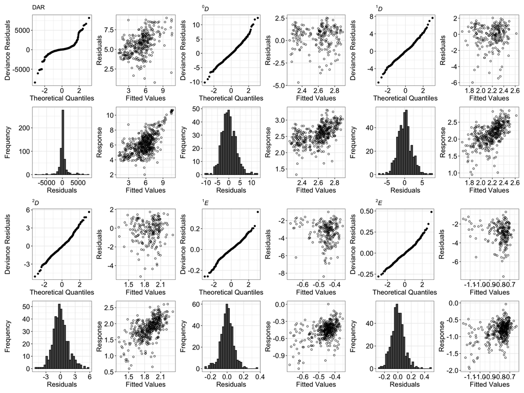

```r
gam_t$DAR$title <- "DAR"
gam_t$d0$title <- expression(""^0*italic(D))
gam_t$d1$title <- expression(""^1*italic(D))
gam_t$d2$title <- expression(""^2*italic(D))
gam_t$e1$title <- expression(""^1*italic(E))
gam_t$e2$title <- expression(""^2*italic(E))

lapply(gam_t, FUN=function(x){
  p1<- ggplot() +
    stat_qq(aes(sample = residuals(x))) +
    labs(x = "Theoretical Quantiles", y = "Deviance Residuals", title = parse(text=x$title))+
    theme_bw() %+replace% large
  p2 <- ggplot(data=cbind(p=predict(x), r=residuals(x))) +
    geom_point(aes(x=p, y=log(r)), shape = 1) +
    labs(x = "Fitted Values", y = "Residuals")+
    theme_bw() %+replace% large
  p3 <- ggplot() +
    geom_histogram(aes(residuals(x)), colour="black") +
    labs(x = "Residuals", y = "Frequency")+
    theme_bw() %+replace% large
  p4 <- ggplot() +
    geom_point(aes(x= predict(x), y = log(x$y)), shape = 1) +
    labs(x = "Fitted Values", y = "Response")+
    theme_bw() %+replace% large
  p1+p2+p3+p4
}) %>% wrap_plots
```

## 5.5 Soomth compnents of the fitted GAM

```r
gam_pred <- lapply(gam_t, FUN=function(x){
  out <- plot(x, residuals = TRUE, page=1)
  names(out) <- names(x$model)[names(x$model) %in% c("Age_ka", "SST", "TOC", "TN", "TP", "TIC", "Dino")]
  lapply(out[!names(out)=="Age_ka"], FUN = function(x){
    out <- cbind(x$x, x$fit, x$se, x$raw, x$p.resid) %>% as.data.frame
    names(out) <- c("x", "fit", "se", "rug", "p.resid")
    return(out)
  }) %>% ldply(.id = "env")
}) %>% ldply(.id = "var")

gam_pred$label <- factor(gam_pred$var,
                             labels = c("DAR", expression(""^0*italic(D)), expression(""^1*italic(D)),
                                        expression(""^2*italic(D)), expression(""^1*italic(E)),
                                        expression(""^2*italic(E))
                                        ))
```

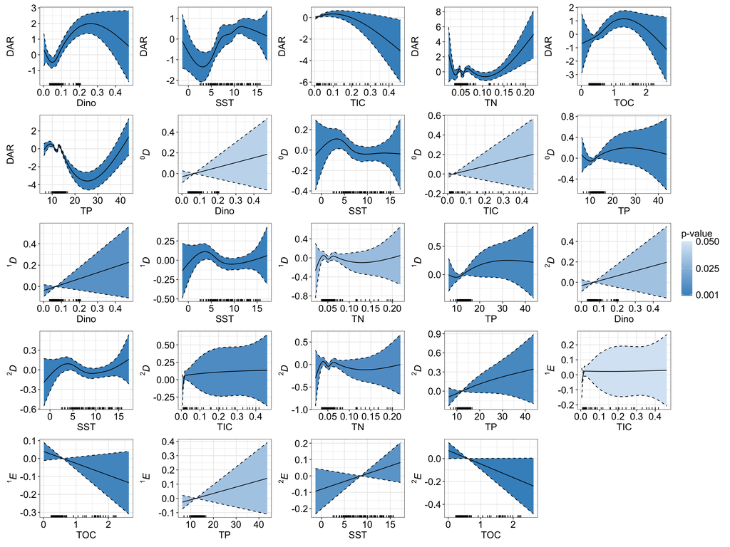

```r
library(stringr)

pv <- lapply(gam_t, FUN = function(x) {
  out <- summary(x)$s.table %>% as.data.frame
  cbind(Term=row.names(out), out)
  }) %>% ldply(.id = "var")

pv$env <- gsub(".*\\((.*)\\).*", "\\1", pv$Term)

keep <- match(with(gam_pred, paste(var, env)), with(pv, paste(var, env)))
gam_pred$pvalue <- pv$`p-value`[keep]

lapply(subset(gam_pred, pvalue<0.05) %>% group_split(var, env), FUN=function(x){
  ggplot(data=x)+
    geom_ribbon(aes(x=x, ymin=fit-se*1.9, ymax=fit+se*1.9, fill=pvalue))+
    #geom_point(aes(x=x, y=fit+p.resid), colour = "gray60")+
    geom_line(aes(x=x, y=fit))+
    geom_line(aes(x=x, y=fit-se*1.9), linetype=2)+
    geom_line(aes(x=x, y=fit+se*1.9), linetype=2)+
    geom_rug(aes(x=rug), sides="b")+
    scale_fill_gradient(low = "#4292c6", high = "#deebf7", breaks = c(0.001, 0.025, 0.05), limits = c(0, 0.05), na.value = "white")+
    labs(x=x$env[1], y = parse(text=as.character(x$label[1])), fill = "p-value")+
    theme_bw() %+replace% large
}) %>% wrap_plots() +
  plot_layout(guides = "collect") & theme(legend.position = "right")
```